# Variables

A Python variable is a symbolic name that refers to a specific memory address where the value is stored.

```python
x = 5
```

Things to remember:

- `x` is name of the variable.
- `=` is the assignment operator used to assign values to variables.
- 5 is the value that `x` refers to.

## When you assign a variable

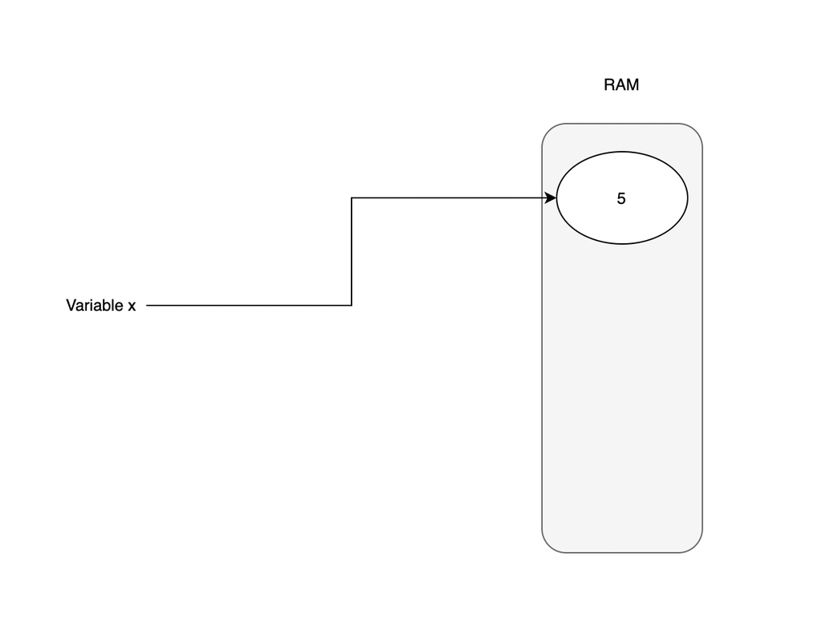

## When you re-assign a variable

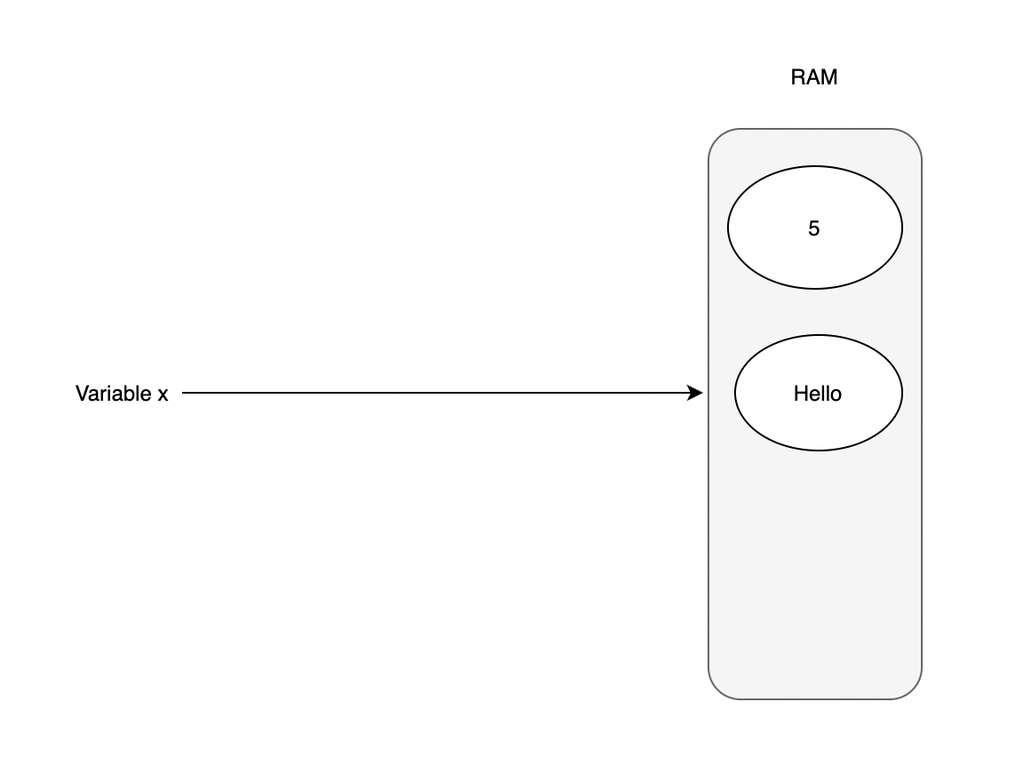

## Rules for naming variables

- Variable names may only contain letters, digits, and/or the underscore character.
- Variable name cannot start with a digit.
- Variable name cannot be a `keyword` in Python.

## Reserved Keywords

- False
- def
- if
- raise
- None
- del
- import
- return
- True
- elif
- in
- try
- and
- else
- while
- as
- except
- lambda
- with
- assert
- finally
- yield
- break
- for
- not
- class
- continue
- pass

# Data Types

## String

```python
name = 'Ajesh'
```

## Numbers

- Integers: `int`
- Floats: `float`

## Sequence

- List: `list`
- example of a list `l = [1, 2, 3]`
- Tuple: `tuple`
- example of a tuple `t = (1, 2, 3)`
- Range: `range`
- example of range: `type(range(0, 10))`

## Mapping

- Dictionary: `dict`
- example of dictionary: `d = {'name': 'Tom', 'age': '30', 'phone': 93979737}`

## Set

- Set: `set`
- example of a set: `s = {'apple', 'banana', 'cherry'}`
- Frozen Set: `frozenset`
- example of a frozenset: `f = frozenset({'apple', 'banana', 'cherry'})`

## Boolean: `bool`

- example of a boolean: `b = True`

## None Type: `None`

## Summary

- Strings
- Number
- Sequence
- Mapping
- Set
- None Type

## Thank You

Do you have any questions?